# Cluster Analysis

ChatGPT 4o

2025-01-21

## 1 起源

聚类分析（Cluster Analysis）是一种探索性数据分析技术，用于将数据集中的观测分成若干组（簇），使得同一组中的对象相似度高，不同组之间的对象相似度低。最早的聚类概念可以追溯到19世纪的生物分类学，用于将生物体按相似性分类。20世纪中期，随着计算机技术的发展，聚类分析在统计学、机器学习等领域中得到了广泛的应用。

## 2 原理

聚类分析的基本原理是通过度量观测点之间的相似性或距离，将相似的观测点归为一组。聚类算法的目标是最大化簇内相似度并最小化簇间相似度。常用的聚类算法包括：

- **K均值聚类（K-means Clustering）**：通过迭代方式将数据分成K个簇，使每个簇内的对象与该簇的中心点的距离最小。
- **层次聚类（Hierarchical Clustering）**：通过构建层次树（dendrogram），逐步合并或分割簇，形成层次结构。
- **密度聚类（DBSCAN）**：基于数据点的密度进行聚类，能够识别任意形状的簇，并且对噪声数据具有鲁棒性。

距离度量方法包括欧氏距离、曼哈顿距离等，不同的距离度量会影响聚类结果。

## 3 适用范围

聚类分析适用于以下情况：

- **无监督学习**：当数据没有明确的标签，需要通过探索性分析揭示数据中的结构或模式时，可以使用聚类分析。
- **样本较大且具有多维特征**：当数据量较大且维度较多时，可以通过聚类来简化数据结构并进行模式发现。
- **市场细分**：用于识别市场中的不同客户群体，进而提供个性化服务或制定针对性的营销策略。

## 4 应用情境

聚类分析在多个领域都有广泛的应用，例如：

- **市场营销**：通过聚类分析识别客户群体，帮助企业制定针对性营销策略。
- **生物信息学**：用于基因表达数据分析，将基因分为不同的功能组。
- **图像处理**：通过聚类技术对图像进行分割，识别不同的区域。
- **社会网络分析**：识别社交网络中的社区结构，帮助理解人际关系网络。

## 5 优缺点

### 优点

- **无需标签**：聚类分析是一种无监督学习方法，不需要预先定义的标签，适用于探索性数据分析。
- **揭示数据结构**：可以揭示数据中的自然分组，帮助理解数据的内在结构。
- **适用性广泛**：可以用于不同类型的数据集，包括数值型、分类型等。

### 缺点

- **结果不唯一**：聚类结果依赖于初始条件和参数的选择，可能导致不同的聚类结果。
- **对异常值敏感**：特别是K均值聚类对异常值较为敏感，可能影响簇的形成。
- **需要指定簇数**：K均值等算法需要预先指定簇的数量，通常需要通过多次试验选择最佳的簇数。

## 6 在R中的实现及结果解释

在R中，可以使用`stats`包中的`kmeans()`函数或`hclust()`函数进行聚类分析。以下是使用K均值和层次聚类的示例：

### K均值聚类

```r
# 加载必要的包
library(ggplot2)

# 示例数据：使用内置的iris数据集
data <- iris[, 1:4]

# 进行K均值聚类，假设分为3个簇
set.seed(123)
kmeans_result <- kmeans(data, centers = 3)
summary(kmeans_result)
```

```
##              Length Class  Mode
## cluster      150    -none- numeric
## centers       12    -none- numeric
## totss          1    -none- numeric
## withinss       3    -none- numeric
## tot.withinss   1    -none- numeric
## betweenss      1    -none- numeric
## size           3    -none- numeric
## iter           1    -none- numeric
## ifault         1    -none- numeric
```

```r
str(kmeans_result)
```

```
## List of 9
##  $ cluster     : int [1:150] 1 1 1 1 1 1 1 1 1 1 ...
##  $ centers     : num [1:3, 1:4] 5.01 5.9 6.85 3.43 2.75 ...
##   ..- attr(*, "dimnames")=List of 2
##   .. ..$ : chr [1:3] "1" "2" "3"
##   .. ..$ : chr [1:4] "Sepal.Length" "Sepal.Width" "Petal.Length" "Petal.Width"
##  $ totss       : num 681
##  $ withinss    : num [1:3] 15.2 39.8 23.9
##  $ tot.withinss: num 78.9
##  $ betweenss   : num 603
##  $ size        : int [1:3] 50 62 38
##  $ iter        : int 2
##  $ ifault      : int 0
##  - attr(*, "class")= chr "kmeans"
```

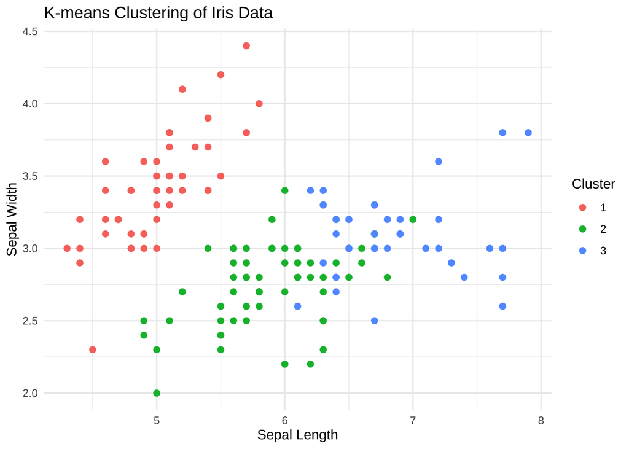

```r
# 将聚类结果添加到数据框中
data$Cluster <- as.factor(kmeans_result$cluster)

# 可视化聚类结果
ggplot(data, aes(x = Sepal.Length, y = Sepal.Width, color = Cluster)) +
  geom_point(size = 2) +
  labs(title = "K-means Clustering of Iris Data", x = "Sepal Length", y = "Sepal Width") +
  theme_minimal()
```

### 层次聚类

```r
# 计算距离矩阵
dist_matrix <- dist(data[, 1:4])

# 进行层次聚类
hclust_result <- hclust(dist_matrix, method = "ward.D2")
summary(hclust_result)
```

```
##             Length Class  Mode
## merge       298    -none- numeric
## height      149    -none- numeric
## order       150    -none- numeric
## labels        0    -none- NULL
## method        1    -none- character
## call          3    -none- call
## dist.method   1    -none- character
```

```r
str(hclust_result)
```

```
## List of 7
##  $ merge      : int [1:149, 1:2] -102 -8 -1 -10 -129 -11 -5 -20 -30 -58 ...
##  $ height     : num [1:149] 0 0.1 0.1 0.1 0.1 ...
##  $ order      : int [1:150] 36 13 2 46 26 10 35 7 3 4 ...
##  $ labels     : NULL
##  $ method     : chr "ward.D2"
##  $ call       : language hclust(d = dist_matrix, method = "ward.D2")
##  $ dist.method: chr "euclidean"
##  - attr(*, "class")= chr "hclust"
```

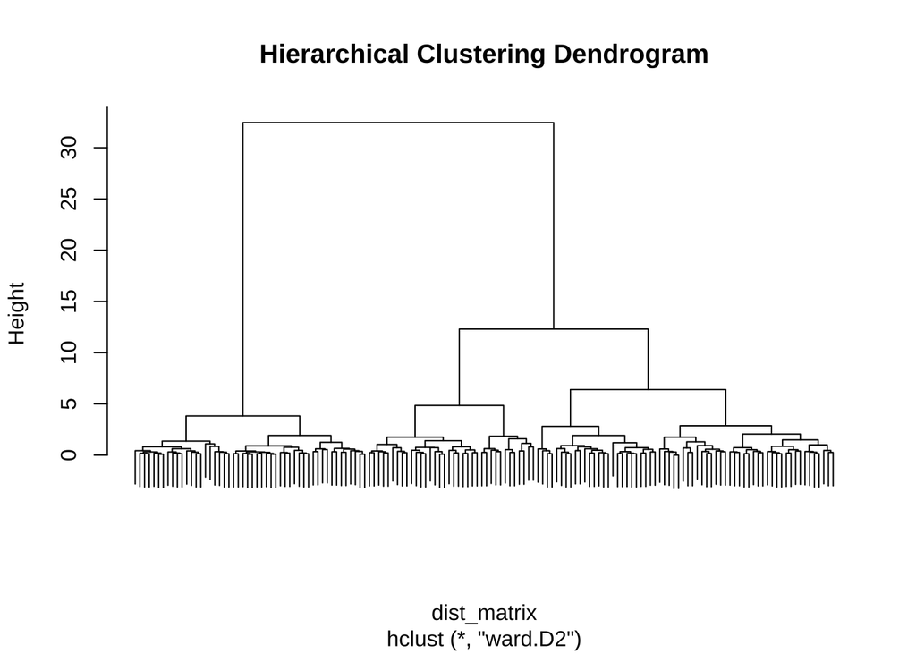

```r
# 绘制聚类树
plot(hclust_result, labels = FALSE, main = "Hierarchical Clustering Dendrogram")
```

### 结果解释

- **K均值聚类结果**：通过`kmeans()`函数对数据进行聚类，结果包括每个簇的中心点、每个样本的簇归属等。可视化结果通过散点图展示了不同簇的数据分布。
- **层次聚类结果**：通过`hclust()`函数进行层次聚类，使用`dendrogram`展示了聚类过程中的合并关系。通过观察聚类树，可以选择合适的切割位置来确定簇数。

## 7 小结

- 聚类分析是一种无监督学习技术，旨在揭示数据中的自然分组和模式。
- 适用于无标签的数据，能够帮助发现数据的结构和潜在的群体特征。
- 常用的聚类算法包括K均值聚类、层次聚类和密度聚类，适用于不同的数据类型和应用场景。
- 聚类分析具有揭示数据结构、无需标签等优点，但对异常值敏感，结果依赖于参数选择。
- 可以通过R中的`kmeans()`和`hclust()`等函数进行聚类分析，并结合可视化直观地展示结果。
- 在市场营销、生物信息学、图像处理等领域，聚类分析是一种重要的工具，用于数据分组和模式发现。